# Data Screening Part 2

Erin M. Buchanan

Last Updated: 2021-01-11

# Data Screening: Next Steps

- In the last lecture, we discussed:
  - Accuracy
  - Missing data
  - Outliers
- What else should we consider for checking our data?

# Data Screening: Assumptions

- For parametric statistics, we should think about:
  - Independence
  - Additivity
  - Linearity
  - Normality
  - Homogeneity (Sphericity), Homoscedasticity

# Data Screening: Assumptions

- The procedure:
  - We will use a ‘fake’ regression to help us analyze these assumptions.
  - It’s ‘fake’ because it’s not part of a real analysis, but just a way to calculate the numbers we need for assessment.
  - When we run regression as a statistical analysis, we can use the real regression in the same way as described below.

# Assumptions: Independence

- **Definition**: the errors in the model should not be related to each other.
- If you do not have independence, confidence intervals and significance tests will be invalid.
- Independence is often a matter of the research design.

# Assumptions: Additivity

- If you have several variables then their combined effect is best described by adding their effects together.
- If two variables are not additive, this implies that the variables are too related, which reduces power.
  - Why use the same variable twice?
  - The “good” thing is called additivity, the violation or “bad” thing is called multicollinearity or singularity.
  - Multicollinearity = r > .90
  - Singularity = r > .95
- This analysis is necessary when you have multiple continuous variables. If you only have one dependent variable, then you cannot run this check.

# Assumptions: Additivity

- You can check this assumption by checking the correlation between the variables.
- If they are too high, you can combine the problematic ones or just one of them.
- Note: we are starting with the same analysis as the last lecture, at the point we ended with.

```r
str(noout)
```

```
## 'data.frame':    117 obs. of  20 variables:
##  $ Sex     : Factor w/ 2 levels "Women","Men": 1 1 1 1 1 1 1 1 1 1 ...
##  $ Age     : int  17 16 15 16 15 14 13 15 16 17 ...
##  $ Grade   : int  11 7 6 11 7 6 4 6 8 11 ...
##  $ SES     : Factor w/ 3 levels "Low","Medium",..: 2 3 3 2 3 3 1 2 2 3 ...
##  $ Absences: int  2 2 2 6 2 2 2 2 1 6 ...
##  $ RS1     : int  6 7 5 7 7 2 6 4 3 4 ...
##  $ RS2     : int  4 1 5 4 7 3 6 6 5 3 ...
##  $ RS3     : int  2 1 5 4 7 2 7 6 3 4 ...
##  $ RS4     : int  2 5 7 7 7 3 6 6 2 4 ...
##  $ RS5     : int  4 7 5 4 7 2 1 6 1 4 ...
##  $ RS6     : int  7 7 6 4 7 3 4 6 7 4 ...
##  $ RS7     : int  7 7 5 7 7 3 6 6 4 4 ...
##  $ RS8     : int  4 7 7 7 7 3 6 6 3 7 ...
##  $ RS9     : int  5 4 6 4 7 2 2 6 3 4 ...
##  $ RS10    : int  7 7 7 7 7 2 5 6 3 4 ...
##  $ RS11    : int  4 1 6 7 7 3 6 6 3 6 ...
##  $ RS12    : int  7 7 6 4 7 3 6 6 2 5 ...
##  $ RS13    : int  4 4 6 7 7 2 6 6 5 6 ...
##  $ RS14    : int  7 7 6 4 7 3 2 6 3 4 ...
##  $ Health  : int  6 6 2 6 4 6 1 2 3 1 ...
```

```r
cor(noout[ , -c(1,4)])
```

```
##                  Age       Grade     Absences        RS1         RS2        RS3
## Age       1.00000000  0.49019725  0.262557530 0.06612470 -0.01559365  0.1334369
## Grade     0.49019725  1.00000000 -0.104392041 0.14860491  0.05664791  0.1173947
## Absences  0.26255753 -0.10439204  1.000000000 0.07070428  0.11606006  0.2093808
## RS1       0.06612470  0.14860491  0.070704285 1.00000000  0.27220381  0.3817913
## RS2      -0.01559365  0.05664791  0.116060064 0.27220381  1.00000000  0.5973382
## RS3       0.13343692  0.11739473  0.209380821 0.38179132  0.59733818  1.0000000
## RS4      -0.08922150 -0.01000726  0.087834549 0.31075603  0.39864823  0.5231247
## RS5       0.16949833  0.11236942  0.083837636 0.30166060  0.31129760  0.4235017
## RS6       0.14978763  0.22428666 -0.016560945 0.26415432  0.49871480  0.4172754
## RS7       0.26290917  0.25822487  0.158061892 0.47033919  0.55712844  0.4573147
## RS8       0.23910245  0.26071552  0.096226510 0.28665462  0.39979778  0.4537863
## RS9       0.03295166  0.02884694 -0.124215415 0.29567642  0.46183267  0.3106902
## RS10      0.06983010  0.20941091  0.112655413 0.39817728  0.60030831  0.4205644
## RS11      0.04612439  0.08860360  0.186183584 0.30878011  0.58776794  0.5389338
## RS12      0.18114033  0.07073961  0.008800693 0.34863143  0.30170481  0.3377878
## RS13      0.08489180  0.10445079  0.140366952 0.34212885  0.68385729  0.6241319
## RS14      0.17819302  0.14265751 -0.047414369 0.28572314  0.36998968  0.4084169
## Health   -0.17616387 -0.13390302  0.033346697 0.01886400 -0.10908427 -0.1672671
##                  RS4        RS5         RS6         RS7         RS8         RS9
## Age      -0.08922150 0.16949833  0.14978763  0.26290917  0.23910245  0.03295166
## Grade    -0.01000726 0.11236942  0.22428666  0.25822487  0.26071552  0.02884694
## Absences  0.08783455 0.08383764 -0.01656094  0.15806189  0.09622651 -0.12421542
## RS1       0.31075603 0.30166060  0.26415432  0.47033919  0.28665462  0.29567642
## RS2       0.39864823 0.31129760  0.49871480  0.55712844  0.39979778  0.46183267
## RS3       0.52312472 0.42350168  0.41727545  0.45731474  0.45378634  0.31069021
## RS4       1.00000000 0.30637059  0.22655970  0.27716895  0.20617182  0.32569474
## RS5       0.30637059 1.00000000  0.43431701  0.37493921  0.44476204  0.44235017
## RS6       0.22655970 0.43431701  1.00000000  0.58033756  0.44402553  0.54589977
## RS7       0.27716895 0.37493921  0.58033756  1.00000000  0.47866309  0.42065613
## RS8       0.20617182 0.44476204  0.44402553  0.47866309  1.00000000  0.42909327
## RS9       0.32569474 0.44235017  0.54589977  0.42065613  0.42909327  1.00000000
## RS10      0.43441072 0.43278751  0.47378753  0.58243841  0.46345363  0.60655022
## RS11      0.38379103 0.50102971  0.56185785  0.51982908  0.44284562  0.59269761
## RS12      0.12074843 0.53610644  0.44461271  0.44719740  0.49635009  0.51310167
## RS13      0.40295975 0.43216174  0.61257699  0.57345227  0.56336407  0.57230209
## RS14      0.21601686 0.55376386  0.55558778  0.51200382  0.44331549  0.59349337
## Health   -0.01278754 0.01944055 -0.03513124 -0.07755897 -0.04959095  0.05310470
##                 RS10        RS11         RS12       RS13        RS14
## Age       0.06983010  0.04612439  0.181140334  0.0848918  0.17819302
```

[output cut: 21 more lines]

```
## RS1       0.01886400
## RS2      -0.10908427
## RS3      -0.16726706
## RS4      -0.01278754
## RS5       0.01944055
## RS6      -0.03513124
## RS7      -0.07755897
## RS8      -0.04959095
## RS9       0.05310470
## RS10     -0.02276861
## RS11     -0.05822418
## RS12     -0.03491826
## RS13     -0.11042056
## RS14     -0.13402642
## Health    1.00000000
```

# Assumptions: Additivity

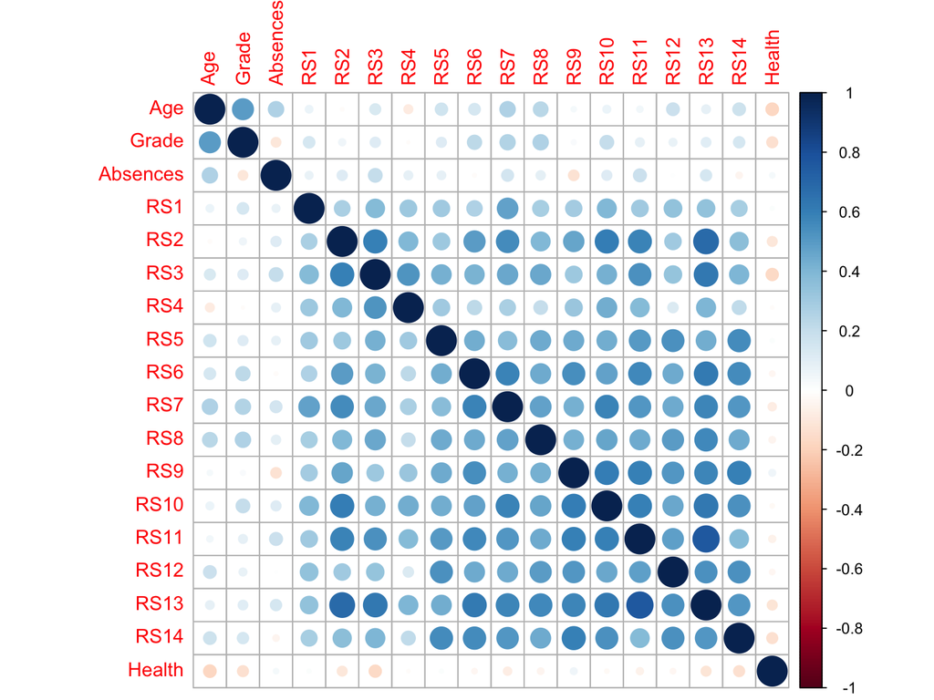

```r
library(corrplot)
corrplot(cor(noout[ , -c(1,4)]))
```

# Assumptions: Linearity

- Assumption that the relationship between variables is linear and not **curved**.
- Most parametric statistics have this assumption including ANOVA, regression, etc.
- Linearity includes both univariate (every variable with every other variable) and multivariate (all the linear combinations together).
- Generally, checking for multivariate linearity can allow you to assess.
- However, if this analysis appears like the assumption is not met, you can check each pairwise combination separately.

# Assumptions: Fake Regression

- At this point, we will create and use our fake regression.
- For many of the statistical tests you would run, there are diagnostic plots / assumptions built into them.
- This guide lets you apply data screening to any analysis, if you wanted to learn one set of rules, rather than one for each analysis.
- But there are still things that only apply to ANOVA that you’d want to add when you run ANOVA. We will learn these in each analysis section.

# Assumptions: Fake Regression

- For the fake regression, we will first create a fake regression.
- As a reminder, we talked about using chi-square for Mahalanobis distance as our cut off score.
- In a similar fashion, we will use chi-square because the errors should be chi-square distributed (lots of small errors, only a few big ones).
- However, the standardized errors should be normally distributed around zero (because they have been standardized!).

# Assumptions: Fake Regression

```r
random <- rchisq(nrow(noout), 7) #why 7? It works, any number bigger than 2
fake <- lm(random ~ ., #Y is predicted by all variables in the data
           data = noout) #You can use categorical variables now!
standardized <- rstudent(fake)
fitvalues <- scale(fake$fitted.values)
```

# Assumptions: Linearity

- With this setup, we can use a couple options to get a QQ plot (sometimes you’ll see PP plots, same idea).

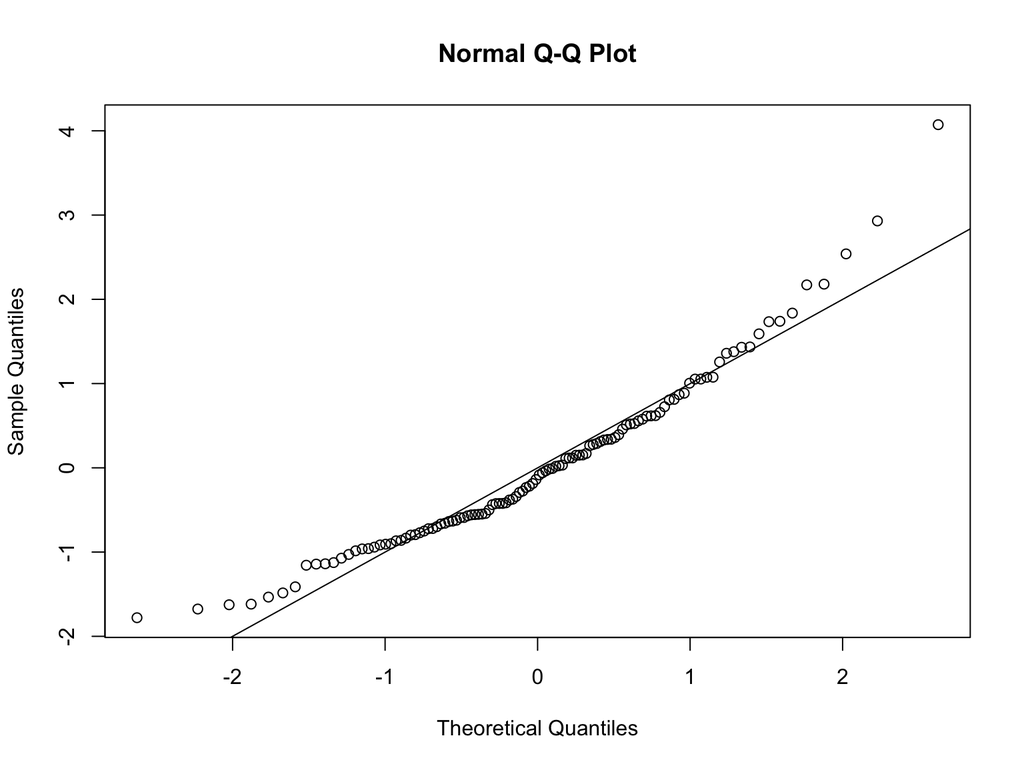

```r
{qqnorm(standardized)
abline(0,1)}
```

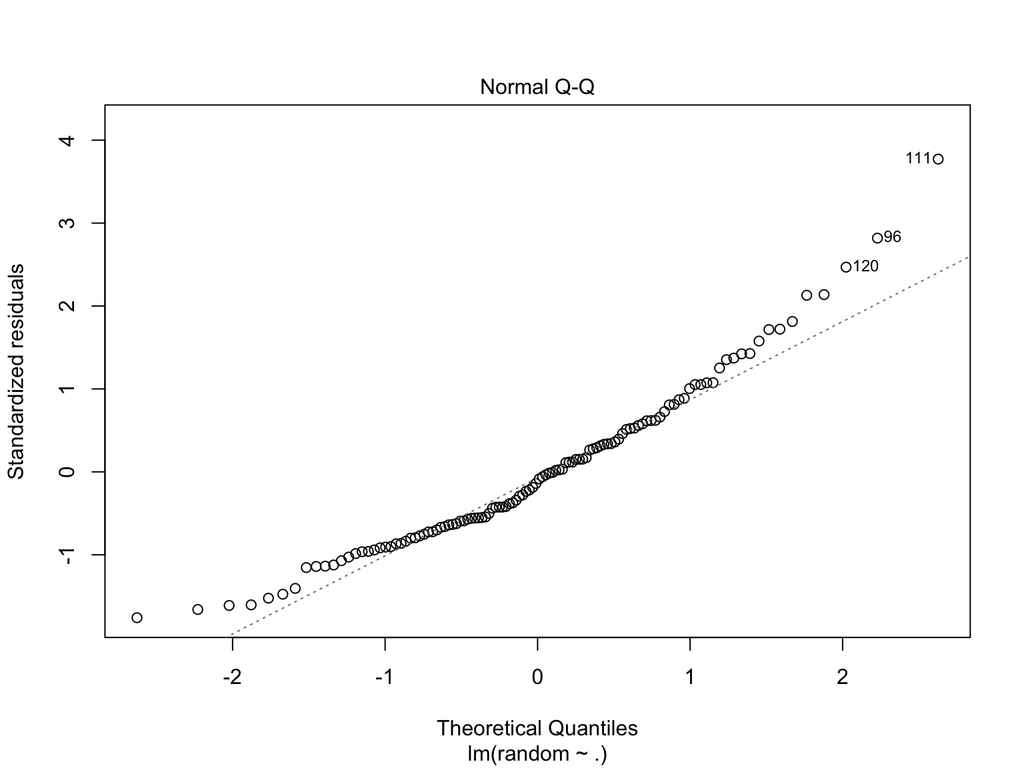

```r
plot(fake, 2)
```

# Assumptions: Linearity

- What are the dots on these plots?
- Regression is a model that we’ve discussed: $Outcome_i = (bX_i) + error_i$
- We are predicting the outcome of a random variable, so the errors **should** be randomly distributed - lots of small numbers that are centered around zero.
- We standardized the errors to help us interpret them by having a scale to compare to.
- Each dot represents a person’s standardized residual plotted against the theoretical residual for that area of the standardized distribution.
- What should I look for? Remember how most of data is between -2 and 2 in a standardized distribution, so we want the dots to line up on the line between -2 and 2 especially.
- Outside that range can be very hard to predict, so we check it, but less concerned if it curves away from the line.

# Assumptions: Linearity

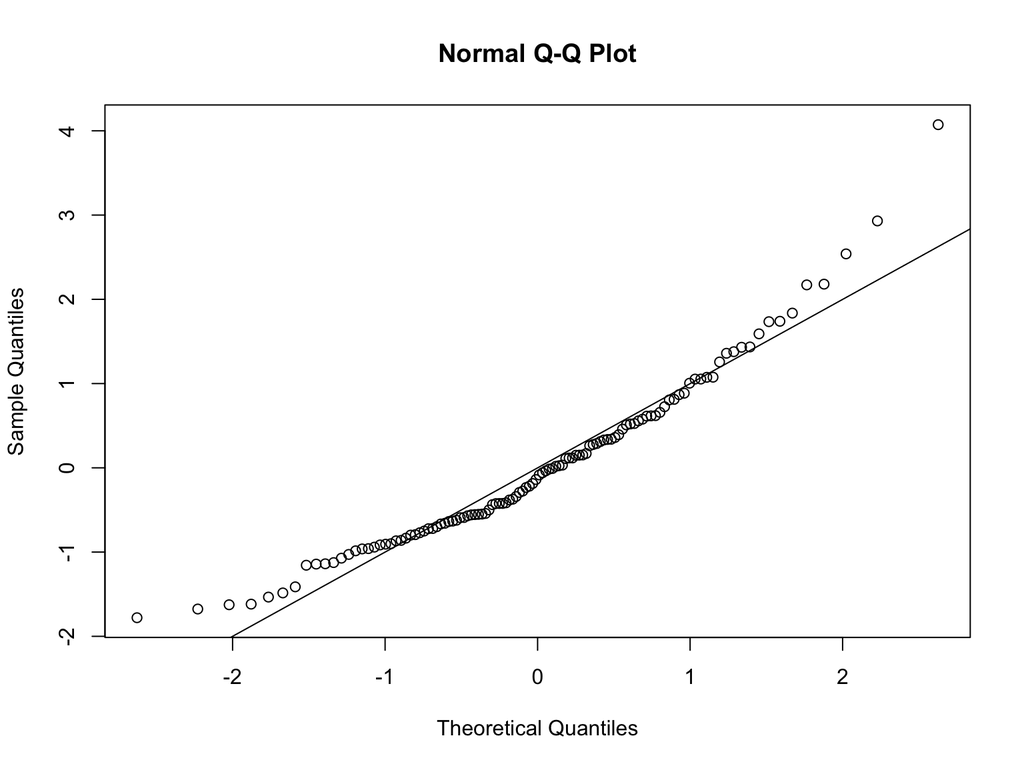

```r
{qqnorm(standardized)
abline(0,1)}
```

# Assumptions: Normality

- This assumption tends to get incorrectly translated as *your data need to be normally distributed.*
- The actual assumption is that the **sampling distribution** is normally distributed.
- Remember the Central Limit Theorem - at what point is the sample size large enough to assume normality?
  - N > 30
  - In practical terms, as long as your sample is fairly large, outliers are a much more pressing concern than normality.
- Check out the sample distribution of residuals as an approximation for multivariate normality.
  - The same idea applies - if multivariate normality is not met, you can check the distribution of each variable to determine which ones might be the problem.

# Assumptions: Normality

- From our earlier lectures, we covered how to check each variable individually - go back and check out those lectures for the comparison rules for concerning values.

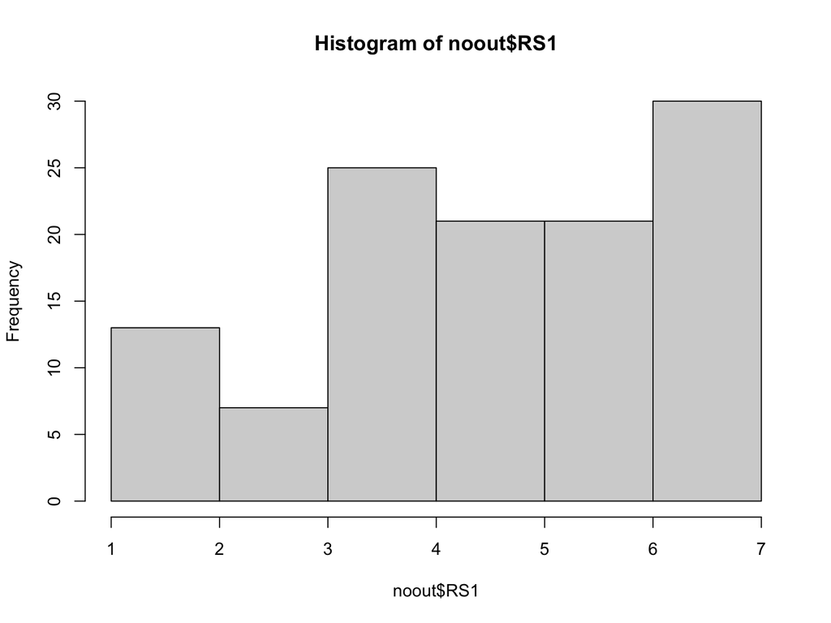

```r
hist(noout$RS1)
```

```r
library(moments)
skewness(noout[ , -c(1,4)])
```

```
##         Age       Grade    Absences         RS1         RS2         RS3
## -0.19702738  0.15301536  0.49126926 -0.64667843 -0.36906000  0.05685151
##         RS4         RS5         RS6         RS7         RS8         RS9
## -0.35137826 -0.08877156 -0.40482052 -0.69937409 -0.17794369 -0.29108181
##        RS10        RS11        RS12        RS13        RS14      Health
## -0.60094634 -0.27412331 -1.08481007 -0.50635999 -0.42755610  0.16841935
```

```r
kurtosis(noout[ , -c(1,4)]) - 3 #to get excess kurtosis
```

```
##        Age      Grade   Absences        RS1        RS2        RS3        RS4
## -1.2256785 -0.6586448 -1.1028824 -0.3777478 -0.7980727 -0.9952655 -1.0297459
##        RS5        RS6        RS7        RS8        RS9       RS10       RS11
## -1.1139551 -0.8420433 -0.2803345 -1.2860668 -0.7436114 -0.6937934 -1.0187545
##       RS12       RS13       RS14     Health
##  0.3725437 -0.6410222 -0.7476452 -1.2699206
```

# Assumptions: Normality

- To check for multivariate normality, we can check a histogram of the standardized residuals.
- We want our distribution to be centered over zero, with most of the data between -2 and 2.
- In this example, we might have slight positive skew, but it is mostly normal.

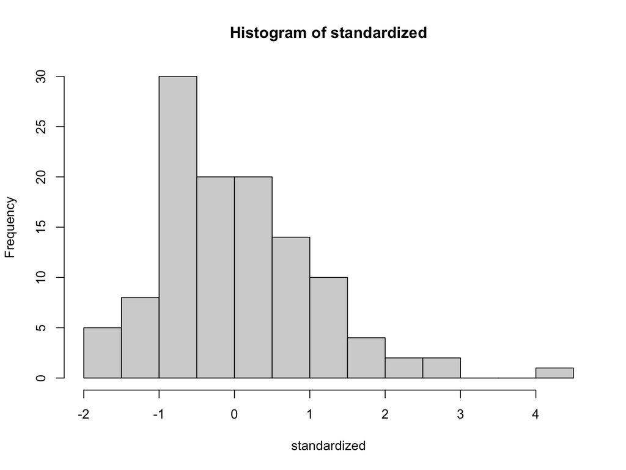

```r
hist(standardized, breaks=15)
```

```r
length(standardized)
```

[output not shown]

# Assumptions: Homogeneity

- Assumption that the variances of the variables are roughly equal.
- **Ways to check:** you do *NOT* want p < .001:
  - Levene’s - Univariate
  - Box’s - Multivariate
  - We will use those with their specific analysis.
- **Sphericity** - the assumption that the differences between measurements in repeated measures have approximately the same variance and correlations.
  - Mauchley’s Test

# Assumptions: Homogeneity

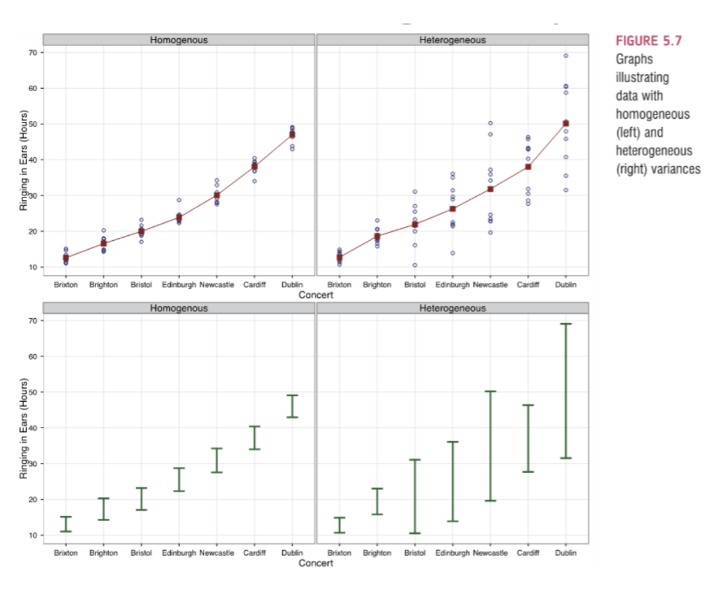

# Assumptions: Homoscedasticity

- Spread of the variance of a variable is the same across all values of the other variable
- Therefore, the variance of Y is the same at each spot of X.

# Assumptions: Homogeneity and Homoscedasticity

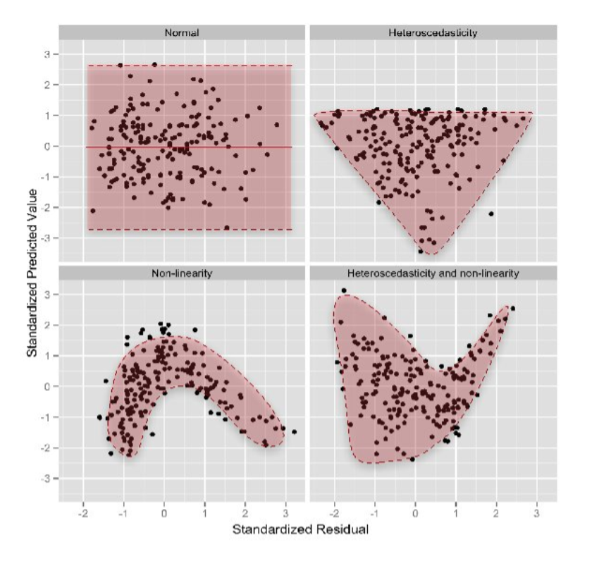

# Assumptions: Homogeneity and Homoscedasticity

- Create a scatterplot of the fake regression.
  - X = Standardized Fitted values = the predicted score for a person in your regression.
  - Y = Standardized Residuals = the difference between the predicted score and a person’s actual score in the regression $Y - \hat{Y}$.
  - Make them both standardized for an easier scale to interpret.
- **In theory, the residuals should be randomly distributed (hence why we created a random variable to test with).**
- Therefore, they should look like a bunch of random dots (see below).

# Assumptions: Homogeneity and Homoscedasticity

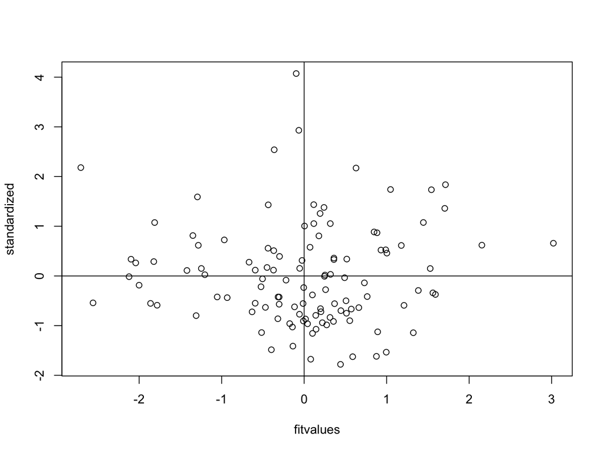

```r
{plot(fitvalues, standardized)
abline(0,0)
abline(v = 0)}
```

# Assumptions: Homogeneity and Homoscedasticity

- **Homogeneity** - is the spread above that line the same as below that 0, 0 line (both directions)?
  - You do not want a very large spread on one side and a small spread on the other side (looks like it’s raining).
- **Homoscedasticity** - is the spread equal all the way across the x axis?
  - Look for megaphones, triangles, or big groupings of data.
  - It should appear to be an even random spread of dots.

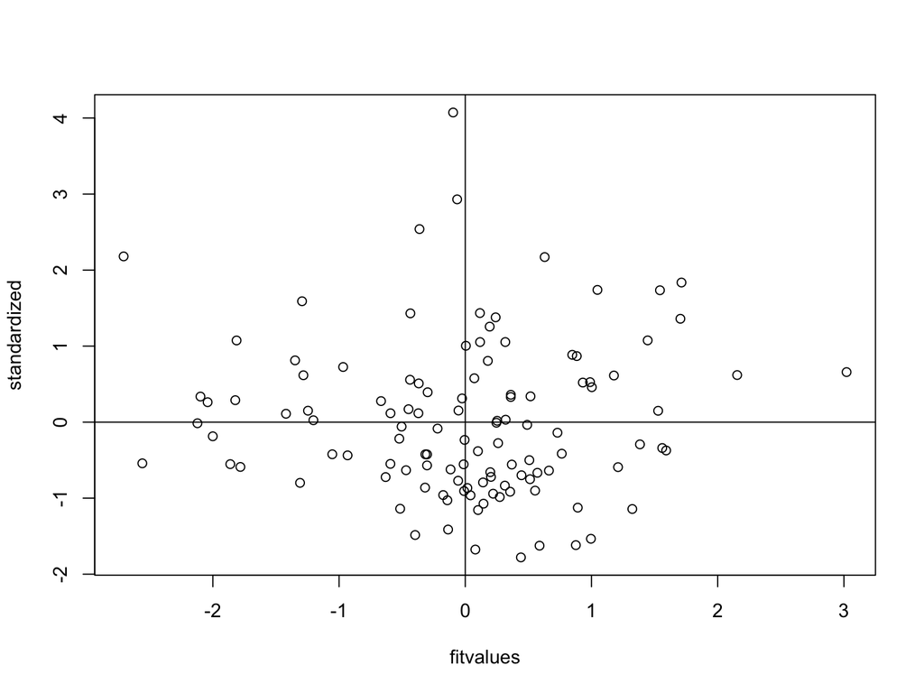

```r
{plot(fitvalues, standardized)
abline(0,0)
abline(v = 0)}
```

# Summary

- In this lecture, we have covered:
  - Independence
  - Additivity
  - Linearity
  - Normality
  - Homogeneity (Sphericity), Homoscedasticity
  - How to plot, interpret, and understand each of these assumptions